# Final Project

Licza Lobo

Mar 23 2026

# Introduction

This project will use publicly available National Health and Nutrition Examination Survey (NHANES) August 2021–August 2023 data to examine socioeconomic and racial disparities in Hepatitis B serologic immunity among U.S. adults aged 20 years and older. The data contains laboratory results for Hepatitis B surface antibody used to assess vaccine-derived immunity, along with respondent-level demographic and socioeconomic variables (age, sex, race/ethnicity, family income to poverty ratio, and education level).

## Analysis Objectives

The final R Markdown report will include a Table 1 summarizing participant characteristics by Hepatitis B immunity. A figure will be presented to illustrate differences in immunity across education levels. In addition, a multivariable logistic regression model will be fitted to estimate adjusted associations between demographic and socioeconomic factors and Hepatitis B immunity, with results presented in a regression table.

## Tabular Analysis

Characteristics of the 5648 U.S. adults aged 20 years or older with available Hepatitis B immunity data from the 2021–2023 NHANES survey cycle are presented in Table 1, stratified by Hepatitis B immunity status.

| **Characteristic** | **Overall** N = 5,648<sup>1</sup> | **Immune** N = 1,415<sup>1</sup> | **Not Immune** N = 4,233<sup>1</sup> | **p-value**<sup>2</sup> |
| --- | --- | --- | --- | --- |
| Gender |  |  |  | 0.004 |
| Female | 3,107 (55%) | 826 (58%) | 2,281 (54%) |  |
| Male | 2,541 (45%) | 589 (42%) | 1,952 (46%) |  |
| Ethnicity |  |  |  | <0.001 |
| Asian | 310 (5.5%) | 148 (10%) | 162 (3.8%) |  |
| Black | 662 (12%) | 209 (15%) | 453 (11%) |  |
| Hispanic | 957 (17%) | 234 (17%) | 723 (17%) |  |
| Other Race | 359 (6.4%) | 96 (6.8%) | 263 (6.2%) |  |
| White | 3,360 (59%) | 728 (51%) | 2,632 (62%) |  |
| Education Level |  |  |  | <0.001 |
| College Graduate or Above | 2,052 (36%) | 623 (44%) | 1,429 (34%) |  |
| High school graduate/GED or equivalent | 1,179 (21%) | 255 (18%) | 924 (22%) |  |
| Less than A High school Education | 698 (12%) | 132 (9.3%) | 566 (13%) |  |
| Some college or Associate's Degree | 1,717 (30%) | 405 (29%) | 1,312 (31%) |  |
| Unknown | 2 (<0.1%) | 0 (0%) | 2 (<0.1%) |  |
| Ratio of family income to poverty | 2.86 (1.47, 5.00) | 3.00 (1.47, 5.00) | 2.82 (1.47, 4.97) | 0.2 |
| Age | 57 (39, 68) | 44 (34, 62) | 60 (43, 69) | <0.001 |

<sup>1</sup> n (%); Median (Q1, Q3)  
<sup>2</sup> Pearson’s Chi-squared test; Welch Two Sample t-test

## Regression Analysis

Below are the results of a multivariable logistic regression model used to evaluate demographic and socioeconomic factors associated with Hepatitis B immunity. Results are reported as odds ratios (ORs) with 95% confidence intervals and global p-values.

| **Characteristic** | **OR** | **95% CI** | **p-value** |
| --- | --- | --- | --- |
| Age | 0.97 | 0.97, 0.98 | <0.001 |
| Gender |  |  | 0.066 |
| Female | — | — |  |
| Male | 0.88 | 0.77, 1.01 |  |
| Ethnicity |  |  | <0.001 |
| Asian | — | — |  |
| Black | 0.58 | 0.43, 0.80 |  |
| Hispanic | 0.38 | 0.28, 0.51 |  |
| Other Race | 0.47 | 0.33, 0.67 |  |
| White | 0.37 | 0.28, 0.48 |  |
| Education_Level |  |  | <0.001 |
| College Graduate or Above | — | — |  |
| High school graduate/GED or equivalent | 0.62 | 0.50, 0.76 |  |
| Less than A High school Education | 0.53 | 0.40, 0.70 |  |
| Some college or Associate's Degree | 0.70 | 0.59, 0.83 |  |
| Unknown | 0.00 |  |  |
| Ratio of family income to poverty | 0.99 | 0.94, 1.04 | 0.6 |

Abbreviations: CI = Confidence Interval, OR = Odds Ratio

## Figure 1: Immunity by Education Level

This figure visualizes the proportion of individuals with vaccine-Induced Hepatitis B Immunity across education levels.

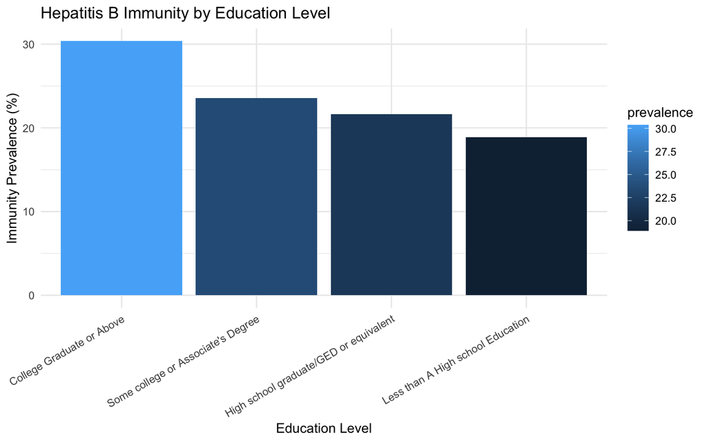